# Forks and Branches using the GitHub website

In this section, we will be using the GitHub.com website and demonstrate that you do not need to be a programmer to use version control and edit files on GitHub.

**Don’t have a GitHub account?**

If you have not already created a GitHub username, please do so now:

- GitHub: https://github.com
- Follow optional [advice on choosing your username](https://happygitwithr.com/github-acct.html)

**Our asks**

### As a Team of two

- Help each other, everyone is bringing different skills! Talk it out!
- Listen to each other; avoid judgment and solutioneering.
- Have fun!

### Prompt

We want to log the information about people’s favorite desserts using a repository.

### Setup

#### Person 1 (owner):

- Create a repository named `favorite-desserts-*myusername*` using these [instructions](https://docs.github.com/en/github/getting-started-with-github/create-a-repo) steps 1-6

[figure not shown]

- Edit the `README.md` to:
  - Click on the pen at the top of the `README.md` file

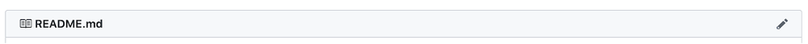

- Replace the title (first line starting with `#`) with something better! Maybe `Favorite Desserts`
- Add your name and your favorite dessert below the title: e.g. `- Julien: crepes`

You should now have a README similar to this:

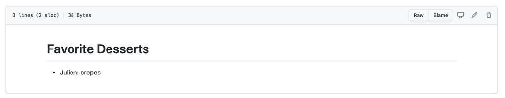

### Forks

#### Person 2: Create a Fork

- Ask your teammate to Slack you the link to the repository
- Create a Fork by clicking on the Fork button on the top right view of your repository homepage

[figure not shown]

- On your Fork, start editing the `README.md`
- Add your name and your favorite dessert below your teammate entry: e.g. `- Sophia: chocolate`
- Add a descriptive commit message

[figure not shown]

- Commit your changes
- Create a pull request to merge those changes to the main repository using these [instructions](https://docs.github.com/en/pull-requests/collaborating-with-pull-requests/proposing-changes-to-your-work-with-pull-requests/creating-a-pull-request-from-a-fork)

#### Person 1:

- Go to *your* repository and merge the PR

### Branches

#### Person 1: add a file

Download this [csv file](https://aurora.nceas.ucsb.edu/~brun/favorite_desserts.csv) about your favorite desserts to your computer

- Just drag and drop it on the Github web page of your repository to upload it
- Add a short message about the file: e.g. `Add favorite_desserts.csv` & hit `Commit changes`
- Your file has been uploaded. Click on the filename to see it!

You should have something similar to this repo: https://github.com/brunj7/favorite-desserts/blob/master/favorite_desserts.csv

Now you want to collaborate more closely and do not want your teammate to have to create a fork and be able to work directly on your repository

- Add Person 2 as a collaborator following these [instructions](https://docs.github.com/en/github/setting-up-and-managing-your-github-user-account/inviting-collaborators-to-a-personal-repository)

#### Person 2: Create a branch

- Check your email or GitHub Notifications to accept the invitation
- Go to the repository website (link is provided in the invitation)
- Create a new branch named after your first name

[figure not shown]

- Edit the csv file directly on GitHub to add your favorite dessert to it
- Create a **P**ull **R**equest (PR) to merge your branch back to `main`
- Assign person 1 as a reviewer ([instructions](https://docs.github.com/en/pull-requests/collaborating-with-pull-requests/proposing-changes-to-your-work-with-pull-requests/requesting-a-pull-request-review))

#### Person 1: Merge the branch

- Review PR
- Merge and close PR

*No need to be a programmer to contribute to analytical workflows with GitHub!!*

Back to main [Repo](https://github.com/EDS-214/eds214-handson-ghcollab)